# Week1: Linear Models

## Question 7

This question focuses on the collinearity problem

## (a) Perform the following commands in `Python`

```python
import numpy as np

np.random.seed(1)

x1 = np.random.uniform(size=100)

x2 = 0.5 * x1 + np.random.normal(size=100) / 10

y = 2 + 2 * x1 + 0.3 * x2 + np.random.normal(size=100)
```

The last line corresponds to creating a linear model in which $y$ is a function of $x_1$ and $x_2$. Write out the form of the linear model. What are the regression coefficients?

The linear model can be written as:

y = intercept + coefficient for x1 + coefficient for x2

In this model:

y is the dependent variable and x1 and x2 are the independent variables.

The regression coefficients are:

intercept = 2; coefficient for x1 = 2; coefficient for x2 = 0.3

## (b) What is the correlation between $x_1$ and $x_2$? Create a scatterplot displaying the relationship between the variables.

link to correlation function: https://numpy.org/doc/stable/reference/generated/numpy.corrcoef.html

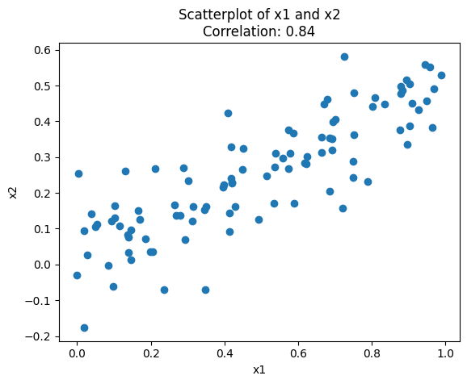

```
Correlation between x1 and x2: 0.84
```

```python
# BEGIN SOLUTION

#Calculating the correlation
correlation = np.corrcoef(x1, x2)[0, 1]

plt.scatter(x1, x2)
plt.xlabel('x1')
plt.ylabel('x2')
plt.title(f'Scatterplot of x1 and x2\nCorrelation: {correlation:.2f}')
plt.show()

#Print the correlation coefficient
print(f"Correlation between x1 and x2: {correlation:.2f}")
# END SOLUTION
```

## (c) Using this data, fit a least squares regression to predict $y$ using $x_1$ and $x_2$. Describe the results obtained. What are $β_0$, $β_1$, and $β_2$? How do these relate to the true $β_0$, $β_1$, and $β_2$? Can you reject the null hypothesis $H_0$: $β_1$ = 0? How about the null hypothesis $H_0$: $β_2$ = 0?

```python
# BEGIN SOLUTION

#Create the design matrix with a constant term for β0
X = sm.add_constant(np.column_stack((x1, x2)))

model4 = sm.OLS(y, X).fit()

model_summary = model4.summary()

print(model_summary)

# END SOLUTION
```

```
                            OLS Regression Results
==============================================================================
Dep. Variable:                      y   R-squared:                       0.261
Model:                            OLS   Adj. R-squared:                  0.245
Method:                 Least Squares   F-statistic:                     17.09
Date:                Tue, 26 Mar 2024   Prob (F-statistic):           4.40e-07
Time:                        18:24:32   Log-Likelihood:                -142.34
No. Observations:                 100   AIC:                             290.7
Df Residuals:                      97   BIC:                             298.5
Df Model:                           2
Covariance Type:            nonrobust
==============================================================================
                 coef    std err          t      P>|t|      [0.025      0.975]
------------------------------------------------------------------------------
const          2.1893      0.199     11.021      0.000       1.795       2.584
x1             0.7046      0.637      1.107      0.271      -0.559       1.968
x2             2.5024      1.140      2.194      0.031       0.239       4.766
==============================================================================
Omnibus:                        0.607   Durbin-Watson:                   2.111
Prob(Omnibus):                  0.738   Jarque-Bera (JB):                0.577
Skew:                          -0.179   Prob(JB):                        0.749
Kurtosis:                       2.900   Cond. No.                         14.3
==============================================================================

Notes:
[1] Standard Errors assume that the covariance matrix of the errors is correctly specified.
```

The intercept is close to the true value.

The coefficient for x1 is not a significant predictor of y because its p-value is high.

The coefficient for x2 is significant in predicting y because its p-value is low.

The estimated coefficients do not exactly match the true values due to data noise.

Hence, the regression model suggests that x1 is not a statistically significant predictor of y while x2 is a statistically significant predictor.

**We cannot reject the null hypothesis that x1 = 0** because the p-value for x1 is greater than the significance level (e.g., 0.05), suggesting no significant relationship between x1 and y.

**we can reject the null hypothesis that x2 = 0** because the p-value for x2 is less than the significance level, indicating a significant relationship between x2 and y.

## (d) Now fit a least squares regression to predict $y$ using only $x_1$. Comment on your results. Can you reject the null hypothesis $H_0$: $β_1$ = 0?

```python
# BEGIN SOLUTION

X1 = sm.add_constant(x1)
model5 = sm.OLS(y, X1).fit()
model_summary = model5.summary()
print(model_summary)

# END SOLUTION
```

```
                            OLS Regression Results
==============================================================================
Dep. Variable:                      y   R-squared:                       0.224
Model:                            OLS   Adj. R-squared:                  0.216
Method:                 Least Squares   F-statistic:                     28.26
Date:                Tue, 26 Mar 2024   Prob (F-statistic):           6.68e-07
Time:                        18:25:00   Log-Likelihood:                -144.76
No. Observations:                 100   AIC:                             293.5
Df Residuals:                      98   BIC:                             298.7
Df Model:                           1
Covariance Type:            nonrobust
==============================================================================
                 coef    std err          t      P>|t|      [0.025      0.975]
------------------------------------------------------------------------------
const          2.2486      0.201     11.209      0.000       1.850       2.647
x1             1.8770      0.353      5.316      0.000       1.176       2.578
==============================================================================
Omnibus:                        0.292   Durbin-Watson:                   2.123
Prob(Omnibus):                  0.864   Jarque-Bera (JB):                0.468
Skew:                          -0.003   Prob(JB):                        0.791
Kurtosis:                       2.665   Cond. No.                         4.26
==============================================================================

Notes:
[1] Standard Errors assume that the covariance matrix of the errors is correctly specified.
```

The constant (intercept) is around 2.2486.

The coefficient for x1 is approximately 1.8770.

The R-squared value is 0.224, indicating it explains about 22.4% of the variance.

The F-statistic and its low p-value suggest the model is statistically significant.

When testing the null hypothesis for x1, the very low p-value (0.000) means we can confidently reject the null hypothesis.

This indicates that x1 is a significant predictor in the model, and it's a valuable variable for predicting y.

## (e) Now fit a least squares regression to predict $y$ using only $x_2$. Comment on your results. Can you reject the null hypothesis $H_0$: $β_1$ = 0?

```python
# BEGIN SOLUTION

X2 = sm.add_constant(x2)
model6 = sm.OLS(y, X2).fit()

print(model6.summary())

# END SOLUTION
```

```
                            OLS Regression Results
==============================================================================
Dep. Variable:                      y   R-squared:                       0.251
Model:                            OLS   Adj. R-squared:                  0.244
Method:                 Least Squares   F-statistic:                     32.87
Date:                Tue, 26 Mar 2024   Prob (F-statistic):           1.09e-07
Time:                        18:25:21   Log-Likelihood:                -142.97
No. Observations:                 100   AIC:                             289.9
Df Residuals:                      98   BIC:                             295.1
Df Model:                           1
Covariance Type:            nonrobust
==============================================================================
                 coef    std err          t      P>|t|      [0.025      0.975]
------------------------------------------------------------------------------
const          2.2655      0.187     12.145      0.000       1.895       2.636
x1             3.5613      0.621      5.733      0.000       2.329       4.794
==============================================================================
Omnibus:                        0.857   Durbin-Watson:                   2.117
Prob(Omnibus):                  0.651   Jarque-Bera (JB):                0.746
Skew:                          -0.210   Prob(JB):                        0.689
Kurtosis:                       2.946   Cond. No.                         6.48
==============================================================================

Notes:
[1] Standard Errors assume that the covariance matrix of the errors is correctly specified.
```

The results show that the x2 coefficient is statistically significant.

Its p-value is less than 0.05 indicating that we can reject the null hypothesis for x2.

This suggests that x2 has a significant impact on the dependent variable y in the model.

## (f) Do the results obtained in (c)–(e) contradict each other? Explain your answer.

The results indicate that both x1 and x2 individually have a significant impact on y.

However, when they are analyzed together, only x2 shows a significant effect.

This shows the significance of considering predictors individually and in combination when interpreting regression results.

## (g) Now suppose we obtain one additional observation, which was unfortunately mismeasured. Re-fit the linear models from (c) to (e) using this new data. What effect does this new observation have on each of the models? In each model, is this observation an outlier? A high-leverage point? Both? Explain your answers.

```python
# BEGIN SOLUTION

#New mismeasured observations
new_x1 = 0.8  # New x1 value
new_x2 = 1.2  # New x2 value
new_y = 5     # New y value

#Adding the new observation to the existing data
x1 = np.append(x1, new_x1)
x2 = np.append(x2, new_x2)
y = np.append(y, new_y)

#Predicting y using x1 and x2
X = sm.add_constant(np.column_stack((x1, x2)))
model7 = sm.OLS(y, X).fit()
print("Model 7 summary:")
print(model7.summary())

#Predicting y using x1
X = sm.add_constant(x1)
model8 = sm.OLS(y, X).fit()
print("\nModel 8 summary:")
print(model8.summary())

#Predicting y using x2
X = sm.add_constant(x2)
model9 = sm.OLS(y, X).fit()
print("\nModel 9 summary:")
print(model9.summary())

# END SOLUTION
```

```
Model 7 summary:
                            OLS Regression Results
==============================================================================
Dep. Variable:                      y   R-squared:                       0.276
Model:                            OLS   Adj. R-squared:                  0.261
Method:                 Least Squares   F-statistic:                     18.68
Date:                Tue, 26 Mar 2024   Prob (F-statistic):           1.34e-07
Time:                        18:25:52   Log-Likelihood:                -143.42
No. Observations:                 101   AIC:                             292.8
Df Residuals:                      98   BIC:                             300.7
Df Model:                           2
Covariance Type:            nonrobust
==============================================================================
                 coef    std err          t      P>|t|      [0.025      0.975]
------------------------------------------------------------------------------
const          2.2023      0.197     11.206      0.000       1.812       2.592
x1             0.8841      0.544      1.624      0.108      -0.196       1.964
x2             2.0872      0.850      2.455      0.016       0.400       3.774
==============================================================================
Omnibus:                        0.340   Durbin-Watson:                   2.126
Prob(Omnibus):                  0.844   Jarque-Bera (JB):                0.365
Skew:                          -0.134   Prob(JB):                        0.833
Kurtosis:                       2.877   Cond. No.                         11.0
==============================================================================

Notes:
[1] Standard Errors assume that the covariance matrix of the errors is correctly specified.

Model 8 summary:
                            OLS Regression Results
==============================================================================
Dep. Variable:                      y   R-squared:                       0.231
Model:                            OLS   Adj. R-squared:                  0.224
Method:                 Least Squares   F-statistic:                     29.82
Date:                Tue, 26 Mar 2024   Prob (F-statistic):           3.53e-07
Time:                        18:25:52   Log-Likelihood:                -146.43
No. Observations:                 101   AIC:                             296.9
Df Residuals:                      99   BIC:                             302.1
Df Model:                           1
Covariance Type:            nonrobust
```

[output cut: 26 more lines]

```
Covariance Type:            nonrobust
==============================================================================
                 coef    std err          t      P>|t|      [0.025      0.975]
------------------------------------------------------------------------------
const          2.3552      0.174     13.540      0.000       2.010       2.700
x1             3.1590      0.541      5.844      0.000       2.086       4.231
==============================================================================
Omnibus:                        0.274   Durbin-Watson:                   2.142
Prob(Omnibus):                  0.872   Jarque-Bera (JB):                0.320
Skew:                          -0.120   Prob(JB):                        0.852
Kurtosis:                       2.865   Cond. No.                         5.67
==============================================================================

Notes:
[1] Standard Errors assume that the covariance matrix of the errors is correctly specified.
```

In Model 7 it improves the model's fit, but it's not an outlier. In Model 8 it has a minimal impact, and it's not an outlier. In Model 9 it significantly affects the model indicating it might be an outlier.

The new observation impacts each model differently with Model 9 showing the most signicant change suggesting it could be an outlier.

## Question 8

It is claimed that in the case of simple linear regression of $Y$ onto $X$, the $R^2$ statistic is equal to the square of the correlation between $X$ and $Y$. Generate some synthetic data and show that this is the case.

link to correlation function: https://numpy.org/doc/stable/reference/generated/numpy.corrcoef.html

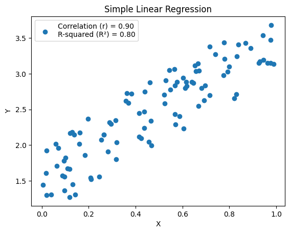

```python
# BEGIN SOLUTION

#Generating the synthetic data
np.random.seed(0)
X = np.random.rand(100)
Y = 2 * X + 1 + np.random.rand(100)
#Calculating the correlation coefficient
r = np.corrcoef(X, Y)[0, 1]

#Calculating R-squared
R_squared = r**2

#Plot the data
plt.scatter(X, Y, label=f'Correlation (r) = {r:.2f}\nR-squared (R²) = {R_squared:.2f}')
plt.xlabel('X')
plt.ylabel('Y')
plt.legend()
plt.title('Simple Linear Regression')
plt.show()

# END SOLUTION
```